# Section 3 Homework Solutions

**Exercise 1**.

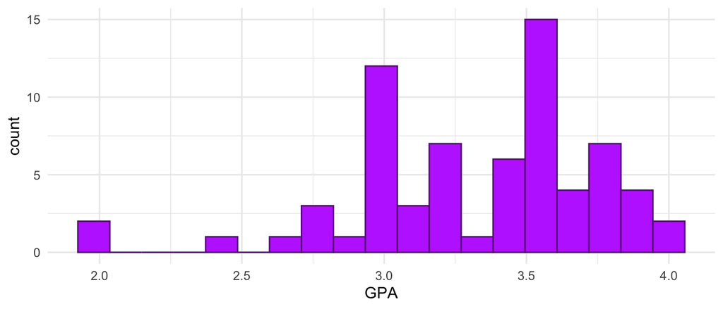

| mean | n |
| --- | --- |
| 3.335 | 69 |

1. $\hat{Y}$ = 3.33,

where $\hat{Y}$ is predicted GPA points.

2. 3.33 points.
3. 3.33 points.
4. -0.83 points.
5. 0.42 points.

**Exercise 2**.

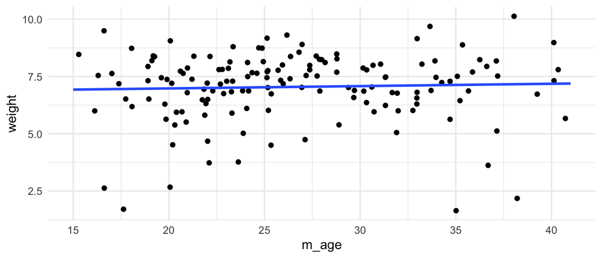

Fitting linear model: weight ~ m_age

|  | Estimate | Std. Error | t value | Pr(>\|t\|) |
| --- | --- | --- | --- | --- |
| **(Intercept)** | 6.775 | 0.5397 | 12.55 | 4.519e-25 |
| **m_age** | 0.01018 | 0.01976 | 0.5151 | 0.6072 |

| weight | m_age | smoke |
| --- | --- | --- |
| 6.88 | 30 | smoker |
| 7.69 | 36 | nonsmoker |

1. $\hat{Y} =$ 6.7753 + 0.0102 X,

where $\hat{Y}$ is predicted weight, and $X$ is mother’s age.

2. weak, slightly positive, and linear.
3. 7.081 pounds.
4. -0.201 pounds.
5. The model is **over**-predicting the baby weight for this mother’s baby, as the residual is negative (meaning that the fitted value is larger than the weight that was actually observed).
6. 7.142 pounds.
7. 0.548 pounds.

**Exercise 3**.

| player_name | ranking | score_average | driving_accuracy | driving_distance |
| --- | --- | --- | --- | --- |
| Dustin Johnson | 1 | 68.7 | 59.46 | 314 |
| Tommy Fleetwood | 2 | 69.34 | 64.98 | 306.9 |
| Justin Thomas | 3 | 69.12 | 58.41 | 311.8 |

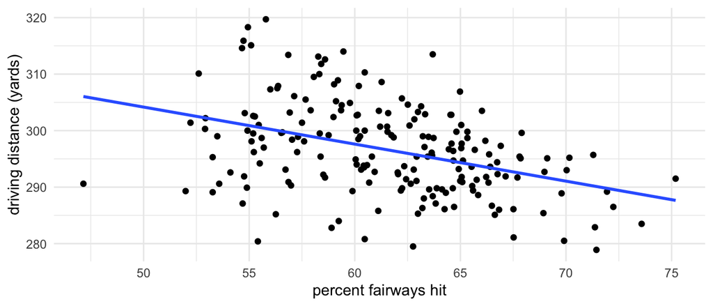

Fitting linear model: driving_distance ~ driving_accuracy

|  | Estimate | Std. Error | t value | Pr(>\|t\|) |
| --- | --- | --- | --- | --- |
| **(Intercept)** | 336.9 | 6.808 | 49.49 | 6.94e-111 |
| **driving_accuracy** | -0.6554 | 0.1104 | -5.939 | 1.335e-08 |

1. $\hat{Y} =$ 336.94 + -0.66 X,

where $\hat{Y}$ is predicted distance in yards, and $X$ is the percent fairways hit.

2. 297.966 yards.
3. 16.034 yards.

**Exercise 4**. Using the birth weight model from the earlier exercise (birth weight of the baby as the response (in pounds) and mother’s age (in years) as the predictor, complete the following.

1. For a one year increase in age of the mother, we expect baby weight to increase by 0.0102 pounds, on average.
2. When age of the mother is 0 years, we expect baby weight to be 6.78 pounds, on average.
3. No: this is extrapolation. There are no mothers in the data set who are 0 years old (this would not make any sense).
4. The percentage of variability in baby weight that can be explained by a model with age of the mother is 0.179%.

**Exercise 5**.

1. For a one percent increase in fairways hit, we expect driving distance to decrease by 0.655 yards, on average.
2. When the percent of fairways hit is 0%, we expect the driving distance to be about 337 yards, on average.
3. No. There are no values even close to 0% fairways hit in the data set so this would be extrapolation.
4. The percentage of variability in driving distance that can be explained by a model with percent fairways hit is 15.59 %.

**Exercise 6**.

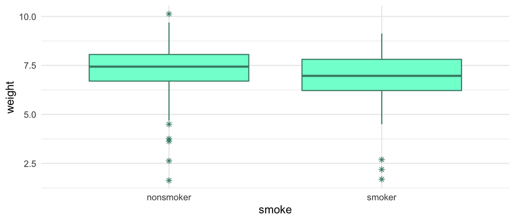

Fitting linear model: weight ~ smoke

|  | Estimate | Std. Error | t value | Pr(>\|t\|) |
| --- | --- | --- | --- | --- |
| **(Intercept)** | 7.18 | 0.149 | 48.18 | 2.398e-92 |
| **smokesmoker** | -0.4005 | 0.2581 | -1.552 | 0.1229 |

| weight | m_age | smoke |
| --- | --- | --- |
| 6.88 | 30 | smoker |
| 7.69 | 36 | nonsmoker |

1. $\hat{Y} =$ 7.1795 + -0.4005 $smoke_{ind}$,

where $\hat{Y}$ is predicted weight, and $smoke_{ind}$ is equal to a $0$ if the mother was not a smoker and a $1$ if the mother was a smoker.

2. 7.18 pounds.
3. 6.78 pounds.
4. 0.101 pounds.
5. For mothers who do not smoke, we expect the average baby weight to be 7.1795 pounds.
6. We expect the average baby weight for mothers who do smoke to be 0.4005 pounds less than the average baby weight for mothers who do not smoke.

**Exercise 7**.

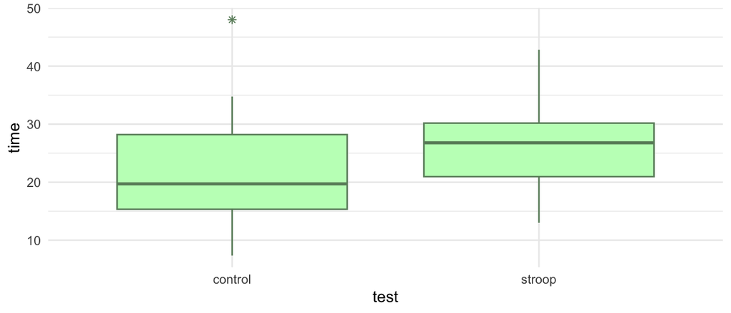

Fitting linear model: time ~ test

|  | Estimate | Std. Error | t value | Pr(>\|t\|) |
| --- | --- | --- | --- | --- |
| **(Intercept)** | 21.8 | 1.892 | 11.52 | 2.733e-15 |
| **teststroop** | 4.383 | 2.503 | 1.751 | 0.08649 |

1. $\hat{Y} =$ 21.8 + 4.383 $test_{ind}$,

where $\hat{Y}$ is the predicted time, and $test_{ind}$ is equal to a $0$ if the person was in the control test group and a $1$ if the person was in the stroop test group.

2. 21.8 seconds.
3. 26.183 seconds.
4. We expect the time to complete the test for people in the control test group to be 21.8 seconds, on average.
5. We expect time to complete the test for people in the stroop test group to be 4.383 seconds more than the the time to complete the test for people in the control test group, on average.